| title: “Data Science 1 : A2” |
| --- |
| author: “Abigail Chen |
| output: pdf_document” |

# Exercise Part 1

Consider the simplest possible regression model
$$Y_i = \beta_0 + \epsilon_i$$
where $\epsilon_i$ *i = 1,…,n* are independent and identically distributed random variables with $E(\epsilon_i)=0$ and $Var(\epsilon_i)=\sigma^2$. The ridge estimator of $\beta_0$ solves.

$$\min_{b}[\sum_{i = 1}^n(Y_i - b)^2+\lambda b^2 ]$$
For some $\lambda\ge0$. In the special case $\lambda=0$, the solution is of course the OLS estimator. (a) Show that the solution to this problem is given by $\hat{beta}_0^{ridge}=\sum_{i = 1}^nY_i/(n+\lambda)$. Compare this to the OLS estimator $\hat{beta}_0^{OLS}=\overline{Y}$.

$$\begin{split}
\min_{b}[\sum_{i = 1}^n(Y_i - b)^2+\lambda b^2 ] = \frac{\partial }{\partial b}[\sum_{i = 1}^nY_i^2 -2b \sum_{i = 1}^nY_i + b^2n +\lambda b^2 ] = 0
\\
-2\sum_{i = 1}^nY_i + 2bn + 2\lambda b = 0 \\
-2\sum_{i = 1}^nY_i + 2b(n+ \lambda) = 0 \\
\beta_{0}^{ridge} = \frac{\sum_{i = 1}^nY_i}{n+ \lambda} \\
\end{split}$$

2. Suppose that $\beta_0=1$ and $\epsilon\sim N(0,\sigma^2)$ with $\sigma^2=4$. Generate a sample of size *n = 10* from a model and compute $\hat{beta}_0^{ridge}$ for a grid $\lambda$ values over the interval $[0, 20]$.

```r
sampleBeta <- function(len_beta) {
    4 / seq(len_beta)^2
}
functionyx <- function(xvalue) {
    beta <- sampleBeta(dim(xvalue)[2])
    xvalue %*% beta
}
```

```r
sim <- function(xgen, x0 = 0.2, lambdas = seq(0, 20, 1)) {
    # sample generator
    xvalue <- xgen()
    y_e <- functionyx(xvalue)
    yvalue <- y_e + rnorm(length(y_e)) * 4


    # x0 value generator
    x_check <- matrix(x0, ncol = dim(xvalue)[2])

    map_df(lambdas, ~{
        model <- glmnet(xvalue,  yvalue, alpha = 0, lambda = .x)
        tibble(
            lambda = .x,
            fhat = as.numeric(predict(model, newx =   x_check )),
            error = as.numeric(functionyx(  x_check )) - fhat
        )
    })
}
```

```r
sim_visualizer <- function(results) {
    group_by(results, lambda) %>%
    summarise(bias2 = mean(error)^2, var = var(fhat)) %>%
    mutate(MSE = bias2 + var) %>%
    pivot_longer(bias2:MSE, names_to = "metric") %>%
    mutate(metric = factor(metric, levels = c("bias2", "var", "MSE"))) %>%
    ggplot(aes(lambda, value, color = metric)) + geom_line(size = 2)
}
```

3. Repeat part *b)*, say 1000 times so that you end up with 1000 estiamtes of $\beta_0$ for all the $\lambda$ values that you have picked. For each value of $\lambda$, compute $bias^2[\hat{beta}_0^{ridge}]$, $Var[\hat{beta}_0^{ridge}]$ and $MSE[\hat{beta}_0^{ridge}]=bias^2[\hat{beta}_0^{ridge}]+Var[\hat{beta}_0^{ridge}]$.

```r
indie <- function(n = 10, p = 1) {
    matrix(rnorm(n * p), nrow = n, ncol = 2)
}
```

```r
# repeat for 1000 times
sim(xgen = indie)
```

```
## # A tibble: 21 × 3
##    lambda  fhat   error
##     <dbl> <dbl>   <dbl>
##  1      0 1.95  -0.954
##  2      1 1.67  -0.669
##  3      2 1.42  -0.423
##  4      3 1.21  -0.210
##  5      4 1.02  -0.0232
##  6      5 0.858  0.142
##  7      6 0.711  0.289
##  8      7 0.579  0.421
##  9      8 0.460  0.540
## 10      9 0.353  0.647
## # … with 11 more rows
```

```r
sim_count <- 1000
sim_2<- map_df(
    seq(sim_count),
    sim,
    xgen = indie
)
```

4. Plot $bias^2[\hat{beta}_{0}^{ridge}]$, $Var[\hat{beta}_{0}^{ridge}]$ and $MSE[\hat{beta}_{0}^{ridge}]$ as a function of $\lambda$ and interpret the result.

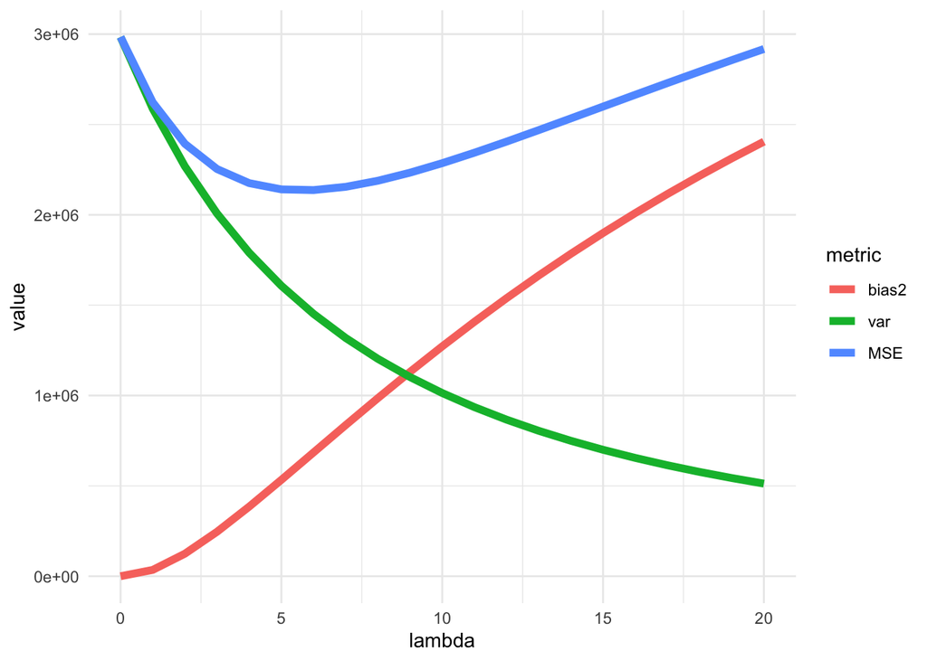

```r
sim_visualizer(sim_2)
```

This figure shows us the increase for bias 2 and the decrease for the variance.

# Exercise Part 2

Let X and Y be two random variables with zero mean. The population version of the optimization problem that defines the first principal component of the two variables is

$$\max_{u1, u2} Var(u_1 X + u_2 Y)$$

Subject to
$$u_1^2 + u_2^2 = 1$$

The following questions ask you to examine some insightful special cases.

1. Suppose that *Var(X)* > *Var(Y)* and *cov(X, Y) = E(XY) = 0*. Derive the first principle component vector. Draw an illustrative picture and explain the result intuitively. (Hint: expand the variance formula and substitute the constraint.Then carry out the minimization.)

$$\begin{split}
Var(u_1 X + u_2 Y) = u_1^2 Var(X) + 2u_1u_2 Cov(X,Y) + u_2^2Var(Y) \\
Cov(X,Y) = 0 \\
u_1^2 Var(X) + 2u_1u_2 0 + u_2^2Var(Y) \\
\text{This is what we'll get} \\
u_1^2 Var(X)+ u_2^2Var(Y) \\
\newline
u_1^2 + u_2^2 = 1 \\
u_1^2 = 1 - u_2^2 \\
\newline
(1 - u_2^2) Var(X)+ u_2^2Var(Y) = 0 \\
Var(X) - u_2^2Var(X) + u_2^2Var(Y) = 0 \\
\frac{\partial }{\partial u_2}(Var(X) - u_2^2Var(X) + u_2^2Var(Y)) = 0 \\
- 2u_2Var(X) + 2u_2Var(Y) = 0 \\
2u_2(-Var(X) + Var(Y)) = 0 \\
u_2 = 0
\newline
u_1^2 + u_2^2 = 1 \\
u_1^2 + 0 = 1 \\
u_1^2 = 1 \\
\sqrt{u_1^2} = \sqrt{1} \\
u_1 = \pm 1 \\
\text {Here is the result} \\
(u_1, u_2) \\
(1, 0), (-1, 0) \\
\text {This shows the result after substitution } u_2^2 \\
(u_1, u_2) \\
(0, 1) , (0, -1) \\
\end{split}$$

After expanding the variance formula and substituting the constraint. The minimization is carried out and this is what we get $(1, 0), (-1, 0), (0, 1)$ and $(0, -1)$.

2. Suppose that *Var(X) = Var(Y) = 1* (principle component analysis is often performed after standardization) and *cov(X, Y ) = E(XY ) = 0*. Show that in this case any vector (u1, u2) with length 1 is a principal component vector (i.e., it solves the problem above). Explain intuitively this puzzling result. (A picture can help.)

$$\begin{split}
Var(X) = Var(Y) = 1\\
cov(X,Y) = E(XY) = 0 \\
Var(u_1 X + u_2 Y) = u_1^2 Var(X) + 2u_1u_2 Cov(X,Y) + u_2^2Var(Y) \\
u_1^2 Var(X)+ u_2^2Var(Y) \\
\newline
u_1^2 + u_2^2 = 1 \\
u_2^2 = 1 - u_1^2 \\
\newline
u_1^2 Var(X) + (1-u_1^2)Var(Y) = 0 \\
u_1^2 Var(X) + Var(Y) -u_1^2Var(Y) = 0 \\
\frac{\partial }{\partial u_1}(u_1^2 Var(X) + Var(Y) -u_1^2Var(Y)) = 0 \\
2u_1 Var(X) - 2u_1Var(Y) = 0 \\
2u_1 (Var(X) - Var(X)) = 0 \\
2u_1 *0 = 0 \\
0=0
\end{split}$$

Here we’ll see that *Var(X) = Var(Y) = 1*, after the principle component analysis(PCA) is performed after standardization. We want to minimize the ellipse size from OLS and circle simultaneously in the given ridge regression.

# Exercise Part 3

ISLR Exercise 3 in Section 6.8: Suppose we estimate the regression coefficients in a linear regression model by minimizing for a particular value of s. For parts (a) through (e), indicate which of i. through v. is correct. Justify your answer.

$$\sum_{i=1}^{n}(y_{i} - {\beta_{0}} - \sum_{j=1}^{p}{\beta_{i}} x_{ij})^2$$
Subject to
$$\sum_{j=1}^{p}|\beta_{j}| \le s$$

- 1. Increase initially, and then eventually start decreasing in an inverted U shape.
- 2. Decrease initially, and then eventually start increasing in a U shape.
- 3. Steadily increase.
- 4. Steadily decrease.
- 22. Remain constant.
1. As we increase s from 0, the training RSS will: When we increase *s* from 0, the training RSS will *(iv) steadily decrease* since the RSS is subject to the given constraint. Our model becomes more flexible as the *s* gets larger, and the restriction of the beta is reducing thus minimizing our RSS.
2. Repeat (a) for test RSS.

As we increase *s* from 0, the test RSS will *(ii) initially decrease* and then increase, making a U shape. If the constraint loosens, the model flexibility and the *s* will both increase.

3. Repeat (a) for variance.

As we increase *s* from 0 the variance *(iii) steadily increase*, because the increase in *s* from 0 means a shrinkage reduction, where lambda is decreasing, resulting to an increase in model flexibility.

4. Repeat (a) for (squared) bias. As we increase *s* from 0, squared bias will *(iv) steadily decrease/* because as the model flexibility increases the bias decreases.
5. Repeat (a) for the irreducible error. As we increase *s* from 0, the irreducible error will, *(v) remain constant* because it is independent of the model parameters making it constant all throughout.